# Atividade 07

Charles Santos

3/26/2021

### **Proposta da atividade**

Utilize o arquivo: [`dados_atividades.csv`](https://raw.githubusercontent.com/thyarles/www.provadigital.com.br/master/est0001/dados_atividades.csv).

1. Calcule média, desvio padrão e os quartis da variável Intromissao.
2. Represente a variável Intromissao por meio de um gráfico de ramo e folhas.
3. Represente a variável Intromissao por meio de um histograma. Utilize 15 classes de valores.
4. Construa boxplots para comparar a Intromissao dos participantes que experimentaram álcool na vida e dos que não experimentaram.
5. Calcule as medidas resumo para a variável Autoeficácia para os três grupos formados pela variável Notas.
6. Construa um diagrama de dispersão com Intromissão, Autoeficácia e Antisocial. Quais são os valores do coeficiente de correlação para esse dados?

**Atenção:** Clique [aqui](https://www.provadigital.com.br/A07.html) para ver a versão renderizada em HTML desta atividade.

#### Pacote necessário para a solução

Para a solução dos problemas o pacote [`ggplot2`](https://github.com/tidyverse/ggplot2).

```r
if (!require(ggplot2)) install.packages(ggplot2)
library(ggplot2)
theme_set(theme_classic())
```

### Solução do item **1**

Calcule média, desvio padrão e os quartis da variável Intromissao.

```r
# Leitura do arquivo dados_atividades.csv
u = "https://raw.githubusercontent.com/thyarles/www.provadigital.com.br/master/est0001/dados_atividades.csv"
dados <- read.csv2(u,  strip.white = TRUE, na.strings = "", encoding = "UTF-8")

# Verificação do sucesso da importação e tipo de ados
str(dados)
```

```
## 'data.frame':    659 obs. of  14 variables:
##  $ ID          : int  1 2 3 4 5 6 7 8 9 10 ...
##  $ Futuro      : chr  "Eu vou ser um grande piloto de dinossauro vivido no Acre," "Calma, tranquila e muito trabalho pra mim trabalhar" "Ter filhos se casa ter um emprego bom termi os estudos e etc," "Um vida muito boa com recursos, uma família e ter filhos e com uma mulher gostosa pra mim ter fi…
##  $ Faltas      : int  4 1 1 3 1 1 1 2 1 2 ...
##  $ Dever       : int  1 5 4 5 5 4 1 3 5 5 ...
##  $ Gosta_escola: int  1 4 3 3 3 4 1 3 2 3 ...
##  $ Notas       : int  1 3 2 1 3 2 1 2 2 3 ...
##  $ Alcool      : int  2 1 1 2 1 1 2 2 2 2 ...
##  $ Inalantes   : int  1 1 1 2 1 1 1 1 1 2 ...
##  $ Sexo        : int  2 2 1 2 2 2 2 2 2 1 ...
##  $ Idade       : int  14 11 11 14 12 13 13 13 13 11 ...
##  $ Ano_escolar : int  7 6 6 NA NA 6 6 7 6 6 ...
##  $ Autoeficacia: num  1.06 1.2 1.46 1.47 1.58 1.6 1.62 1.82 1.95 1.98 ...
##  $ Intromissao : num  1.73 2.44 0.95 4.56 1.46 2.56 4 2.45 5.04 0.87 ...
##  $ Antisocial  : num  1.91 1.07 1.06 4.44 1.1 1.18 2.29 1.36 0.98 1.34 ...
```

```r
# Média (ignorando os NA's)
mean(dados$Intromissao, na.rm = TRUE)
```

```
## [1] 2.465936
```

```r
# Desvio padrão (ignorando os NA's)
sd(dados$Intromissao, na.rm = TRUE)
```

```
## [1] 1.084671
```

```r
# Quartis (ignorando os NA's)
quantile(dados$Intromissao, na.rm = TRUE)
```

```
##   0%  25%  50%  75% 100%
## 0.87 1.68 2.26 3.15 5.07
```

### Solução do item **2**

Represente a variável Intromissao por meio de um gráfico de ramo e folhas.

```r
# Usando a função stem
stem(dados$Intromissao)
```

```
##
##   The decimal point is 1 digit(s) to the left of the |
##
##    8 | 701333445555566666667778888
##   10 | 0000000000011112222333333445556667788890005566677888
##   12 | 0011122234444555688880111112244568
##   14 | 113334455556666777788899000111111111233356679
##   16 | 1344578011111111222223333444444444555555566666666777889
##   18 | 0011122233444901122335555666666777777778888888
##   20 | 0000000111122233334444455566667911677899999999
##   22 | 001112222334444444455556666777778889901111233445
##   24 | 02223344566666677778899990000111122234445566777888
##   26 | 556689001233444445556667778888999
##   28 | 0778113334567777777888888
##   30 | 00000000001111222345556667778995679
##   32 | 0122223455556677778890124
##   34 | 12566667777788999900112445668
##   36 | 399112455799
##   38 | 010114445556677788
##   40 | 000000011233345668899
##   42 | 112344467990
##   44 | 455790069
##   46 | 699556699
##   48 | 367923455556688
##   50 | 01222234567
```

### Solução do item **3**

Represente a variável Intromissao por meio de um histograma. Utilize 15 classes de valores.

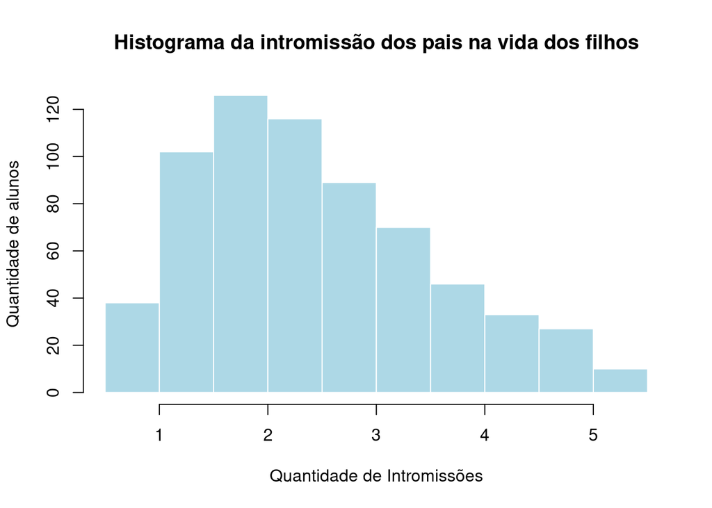

```r
# Nesta questão usar 15 classes parece não ter efeito
# Se coloco 15, aparecem dez... se coloco 20, aparecem 21... não entendi.

hist(dados$Intromissao, xlab = "Quantidade de Intromissões", ylab = "Quantidade de alunos",
     main = "Histograma da intromissão dos pais na vida dos filhos", breaks = 15,
     col = "lightblue", border = "white")
```